# Queria saber…

Nesta seção eu busco entender como anda a criação e publicação dos jogos de tabuleiro ao longo do tempo. Mais especificamente, vamos tentar entender como tem variado a quantidade de jogos criados e publicados entre os anos e décadas, além de quantificar quanto tempo de atraso temos entre a criação de um jogo e a sua publicação no Brasil. Para isso, vamos usar as informações existentes sobre os 500 jogos de tabuleiro mais bem avaliados pela comunidade a partir do site da [Ludopedia](https://www.ludopedia.com.br/ranking). É importante frisar aqui algumas das premissas para essa análise:

1. Os 500 jogos extraídos a partir do ranking da Ludopedia são uma amostra representativa e não enviesada dos títulos existentes;
2. O ano de criação dos jogos representará também o ano em que foram publicados, a não ser para os jogos criados fora do páis e posteriormente publicados aqui - neste caso, contaremos como o ano de publicação aquele informado no site da Ludopedia.

Bom, vamos começar!

# Como anda a publicação dos jogos?

A análise dos dados sobre o ano de criação dos jogos no Top 500 da Ludopedia demonstra que grande parte deles originou-se entre os anos de 2010 e 2020, conforme observado na figura abaixo. Isto pode nos dizer uma ou duas coisas: (1) grande parte dos jogos mais bem avaliados foi criado recentemente e/ou (2) tivemos um *boom* de novos títulos surgindo nessa década - talvez, por conta da popularização do *hobby*, quem sabe.

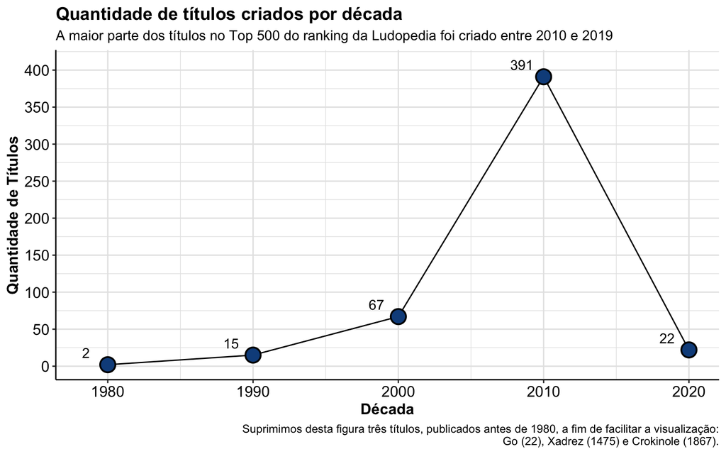

Um ponto importante é que tive que retirar três jogos da base de dados para construir esta visualização e deixá-la mais legível - são eles: o Go (criado em 22), Xadrez (criado em 1475) e Crokinole (criado em 1867). Além disso, note que a série temporal mostrada na figura acima começa a partir de 1980. Isto parece reforçar a ideia de que, embora os jogos de tabuleiro existam há algum tempo, foi somente na última década que houve uma explosão na diversidade de títulos disponíveis.

Outro ponto interessante é apresentado na figura abaixo. Quando comparamos o volume de títulos publicados ao longo do tempo com aqueles publicados no Brasil no mesmo período, podemos observar que foi somente nos últimos anos que estes títulos chegaram por aqui. Mais especificamente, foi em 2018 e 2019 que observamos um grande salto na disponibilização dos títulos no país. Isto parece sugerir que deve exigir algum tipo de atraso considerável para a publicação dos jogos por aqui.

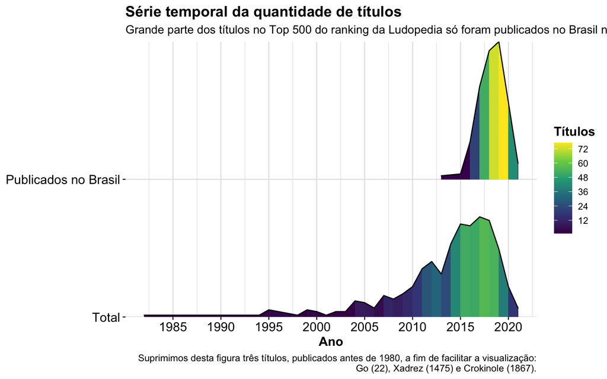

# Quanto tempo leva para um título chegar no Brasil?

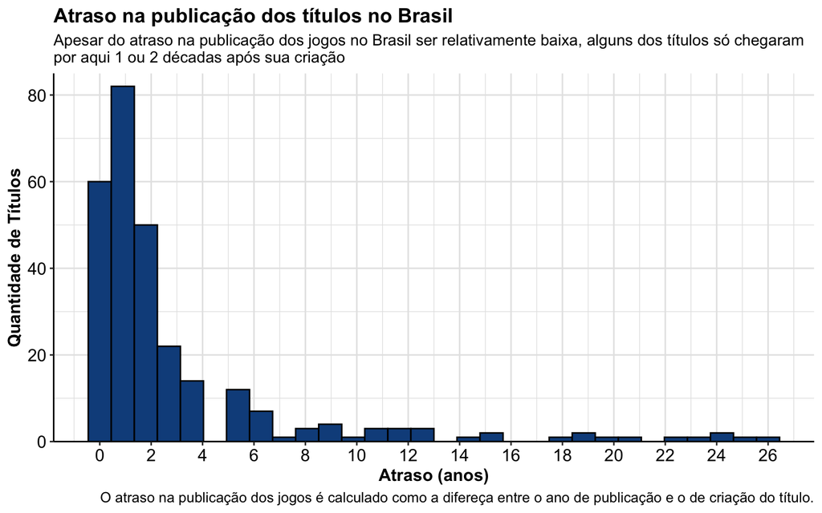

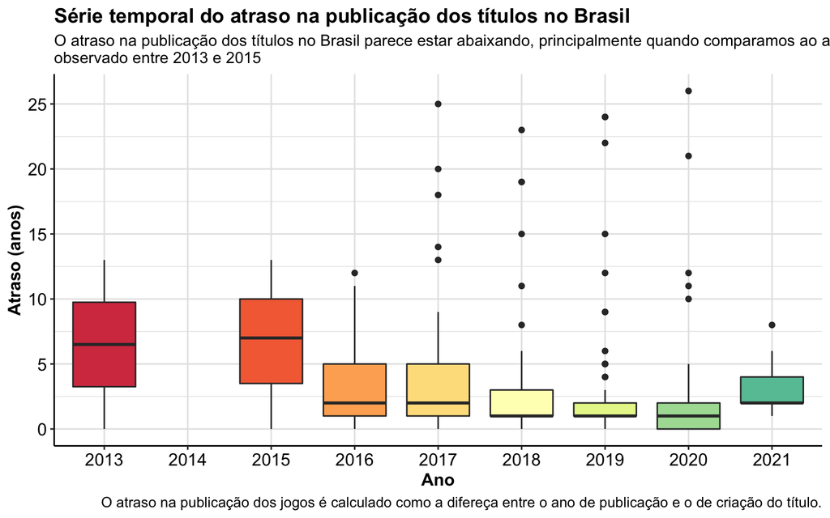

# O que poderia estar associado a estes padrões?

Já vimos que grande parte dos títulos disponíveis foram criados na última década, e que nos últimos anos houve uma disponibilização massiva dos mesmos aqui pelo Brasil. Também apresentamos a hipótese de que o grande volume de títulos na última década pode estar associado à popularização do *hobby*…mas como entender o padrão para o atraso na disponibilização dos jogos aqui pelo Brasil?

Se analisarmos os jogos disponibilizados no Brasil que estão neste ranking do Top 500 da Ludopedia (337 títulos), podemos observar que 13 editoras são responsáveis por cerca de 90% dos mesmos, conforme apresentado na figura abaixo. Destas, a Galápagos Jogos é áquela que apresenta a maior contribuição (32.6% dos títulos), seguida da Devir Brasil (11% dos títulos), Grok Games (fusão da Mandala Jogos e Ludofy Creative; 10.1% dos títulos), Conclave Editora (9.79% dos títulos), MeepleBR (8.61% dos títulos) e PaperGames (6.82% dos títulos). Caso estas editoras tenham surgido e/ou atuado com mais intensidade no Brasil na última década, então pode ser que isto tenha contribuído para aquele padrão de atraso na disponibilização dos títulos por aqui.

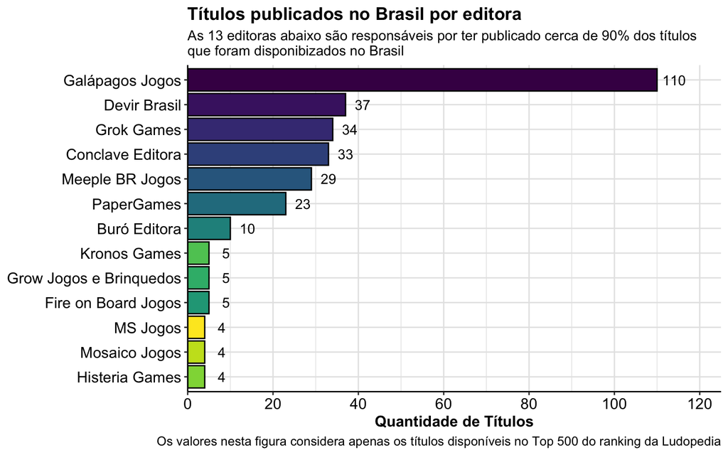

Eu fiz uma busca rápida na internet e vi que grande parte destas editoras surgiram e/ou passaram a atuar na área na última década: a Galápagos Jogos em 2009, a MeepleBR em 2014, a PaperGames em 2016 e a Grok Games em 2019. As exceções à regra seriam a Devir Brasil (fundada em 1987) e a Conclave Editora (fundada em 2003). Não sei se isso fornece as evidências que eu precisava para considerar minha hipótese plausível, mas fica a possibilidade no ar.

# Conclusões

Esta é uma análise bastante preliminar e exploratória da serie histórica sobre o volume de jogos de tabuleiro criados e publicados no Brasil. Utilizamos os dados disponíveis para 500 jogos que estão no site da Ludopedia, assumindo que eles formam uma análise representativa dos jogos disponíveis por aí. Portanto, é necessário cuidado ao interpretar estes padrões ou querer buscar algum tipo de causualidade nos mesmos. Ainda assim, é animador ver o crescente interesse e atividade na área.

Se você curtiu estas análises, tem alguma dúvida, sugestão ou reclamação, é só entrar em contato comigo através do [GitHub](https://github.com/nacmarino) e no [LinkedIn](https://www.linkedin.com/in/nicholas-marino-7590361b).